# STAA57 Final Project Report

Team 10 (Daniela Venturo Esaine, Reizwanul Chowdhury, Ralph Samson Lal, Xiaotong Ye)

## Introduction

“Is university worth it?” is one of the hardest questions to answer because of its broad nature. University is a very different experience from person to person depending on various factors. One of the main concerns of most people is the heavy economical investment university requires. This skews the question towards the idea of measuring worth by future economical gain that pays out the original investment. Therefore, to investigate if university is “worth-it”, it makes sense to calculate the amount of time it takes to amortize total tuition cost in Canada, and factors that affect the amortization process.

To answer this broad question with focus on amortization time, we consider three areas: a. A students immigration status, b. Degree specifications, c. Employability after graduation, Since we believe tuition expenses are affected by these factors.

To analyse the affect of the above mentioned factors on amortization time, we ask the following questions. 1. Is it worth it to get a Bachelor’s degree as a Canadian domestic student compared to an international student? 2. Is it worth it to get a Masters degree as a Canadian domestic student compared to an international student? 3. What is the most “worth-it” field of study? (for undergraduate and graduate, for international and domestic) 4. What is the least “worth-it” field of study? (for undergraduate and graduate, for international and domestic) 5. Is unemployment vastly different between individuals having Non-University education and University Degree?

## Data Descriptions

To answer the questions stated above it is required to get tuition costs depending on graduate and undergraduate levels of study and fields of study. To do that we will web-scrape data from univcan.ca that will let us know the average tuition for graduate and undergraduate degrees. Tables from Statistics Canada will indicate the average tuition for international and domestic students at different fields of study as well as different levels of study and income6.csv will indicate income based on fields of study. To analyse Unemployment we will focus on the Labor Force Survey data set.

## Data Analysis

For our main analysis for question 1 and question 2 we will focus on the overall differences that student type and degree level has on amortization time for students in Ontario.

#### Q1: Is it worth it to get a Bachelor’s degree as a Canadian domestic student compared to an international student?

The following plot shows the tuition of each university in Ontario as an undergraduate student, both domestic and international.

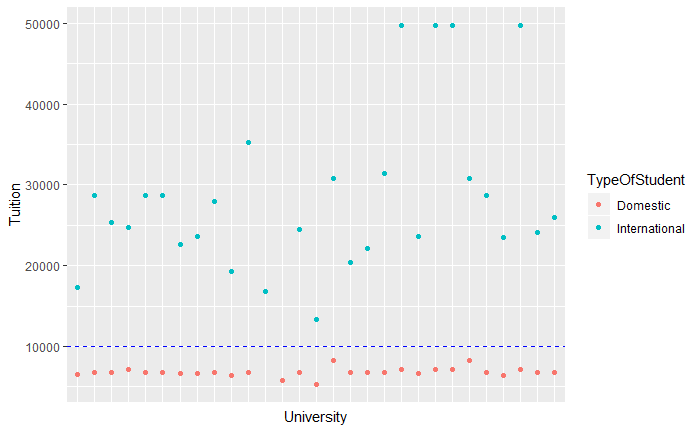

From the above we can see that domestic tuition of the universities in Ontario stay around the same, while the international student tuition varies from university to university greatly while being greater than domestic tuition fees. Since amortization time is proportional to tuition cost, the above separation between domestic and international students caries forward into duration of amortization as well both for undergraduate studies and graduate studies. [this is explored further graphically in the appendix part 1] Lets move onto question 2 to get a better over all picture and also answer question 1.

#### Q2: Is it worth it to get a Masters degree as a Canadian domestic student compared to an international student?

This following bar plot shows the average time to amortize a graduate vs. undergraduate degree as a domestic vs. international student

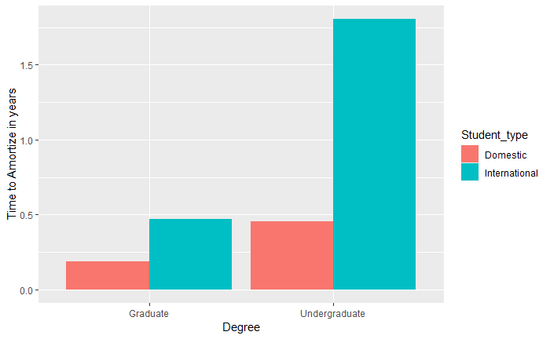

##### Conclusion for question 1 Is it worth it to get a Bachelor’s degree as a Canadian domestic student compared to an international student?:

Most definitely yes, there is considerable difference in time to amortize degree cost between domestic and international student for undergrad. Seeing the above plot we would say it is more worth it to a domestic student to do undergrad than for a international student. But this does not mean its completely not worth it for international students as we explain below.

##### Conclusion for question 2 Is it worth it to get a Masters degree as a Canadian domestic student compared to an international student?:

According to the result above again its is more worth to get a graduates degree as a domestic student than being a international students. International undergraduate tuition are a lot larger than domestic tuition, but according to Q2 analysis, although a graduate degree for international students takes longer to amortize than the domestic it’s not as big of a margin as in the undergraduate degree case as we saw in Q1. So a graduates degree is worth it to both groups of students.

#### Q3: What is the most “worth-it” field of study? (for undergraduate and graduate, for international and domestic)

To find the most and least worth it field of study for each category combination we will be calculating the average yearly tuition fees across 5 years and then based on yearly income per field of study calculate the time to amortize said tuition. The fastest time will correspond to the “Most worth it” field of study. Our Amortization times are denoted in years, and Tuition and Income in CAD, the income will be drawn from Canadian income data sets since we assume students in all of the categories will be working in their desired field of study in Canada. We will only be using the average employment income after tax for each field of study. We also assume that a student gets a job immediately after graduation to start paying off degree cost.

Most worth it field for Canadian Undergraduate:

```r
mostWorthIt(canUndergrad, 4)
```

| Field_of_study | avgTuition | avgIncome | amortizeTime |
| --- | --- | --- | --- |
| Education | 4505.6 | 49516 | 0.3639712 |

Most worth it field for International Undergraduate:

```r
mostWorthIt(interUndergrad, 4)
```

| Field_of_study | avgTuition | avgIncome | amortizeTime |
| --- | --- | --- | --- |
| Education | 17636.6 | 49516 | 1.424719 |

Most worth it field for Canadian Graduate:

```r
mostWorthIt(canGrad, 2)
```

| Field_of_study | avgTuition | avgIncome | amortizeTime |
| --- | --- | --- | --- |
| Law | 5836.8 | 67015 | 0.1741938 |

Most worth it field for International Graduate:

```r
mostWorthIt(interGrad, 2)
```

| Field_of_study | avgTuition | avgIncome | amortizeTime |
| --- | --- | --- | --- |
| Dentistry | 20744 | 96880 | 0.4282411 |

#### Q4: What is the least “worth-it” field of study? (for undergraduate and graduate, for international and domestic)

We follow the same process as in Q3 but define the program with the longest time to be the “least worth it” field of study.

Least worth it field for Canadian Undergraduate:

```r
leastWorthIt(canUndergrad, 4)
```

| Field_of_study | avgTuition | avgIncome | amortizeTime |
| --- | --- | --- | --- |
| Dentistry | 21156.2 | 96880 | 0.8735012 |

Least worth it field for International Undergraduate:

```r
leastWorthIt(interUndergrad, 4)
```

| Field_of_study | avgTuition | avgIncome | amortizeTime |
| --- | --- | --- | --- |
| Visual and performing arts, and communications technologies | 20766 | 38094.67 | 2.180463 |

Least worth it field for Canadian Graduate:

```r
leastWorthIt(canGrad, 2)
```

| Field_of_study | avgTuition | avgIncome | amortizeTime |
| --- | --- | --- | --- |
| Business, management and public administration | 10904.6 | 48760 | 0.4472765 |

Least worth it field for International Graduate:

```r
leastWorthIt(interGrad, 2)
```

| Field_of_study | avgTuition | avgIncome | amortizeTime |
| --- | --- | --- | --- |
| Business, management and public administration | 20919.6 | 48760 | 0.858064 |

#### Q5: Is unemployment vastly different between individuals having Non-University education and University Degree?

The Levels of Education we consider are 2: Gr 11 to 13, graduate, 3: Some post secondary, 4: Post secondary certificate or diploma, 5: University: bachelors degree, 6: University: graduate degree

Is there a significant difference in unemployment rates between individuals holding a bachelors degree vs graduates degree in Ontario?

Is there a significant difference in unemployment rates between individuals holding a Post secondary certificate/diploma vs graduates degree ?

## Summary

Based on the results from question 1 and 2, it is safe to conclude that International student tuition for any degree is higher than Domestic student tuition. However, the gap between tuition is lessened when going from a bachelor’s degree to a masters degree. This means it is easier to pay off a masters degree than a bachelors degree as an international student. Therefore considering amortization time in spite of tuition costs we suggest, it’s better to do graduate studies than undergrad studies as an international student if time to amortize is a concern. Especially if a international student is currently doing undergrad they must consider continuing into graduate studies to gain more benefit.

Regarding questions 3 and 4: an undergraduate degree, for both Canadian and international students, have Education as the most worth it field of study. For Canadian Graduate, it is law and for International Graduates it is Dentistry. Surprisingly, for domestic undergraduate students, Dentistry is the least worthy field of study since it has the highest time to amortize. For domestic graduate students, Business, management, and public administration is the least worthy of study. For international undergraduate students, visual and performing arts, and communications technologies is the least worthy field of study since it has the lowest average income. For international graduate students, Business, management and public administration is the least worth of study, which is same as domestic graduate students. However, by no means does this imply least worth-it programs are not worth it at all. the statistics calculated just implies it is harder to get a good payout from that field.

## Appendix

(*Everything here does not count towards page limit*)

##### Appendix part 1:

###### TIME TO AMORTIZE AS AN UNDERGRADUATE

The following plot shows the average time it takes to amortize as an undergraduate student from each university in Ontario, both domestic and international.

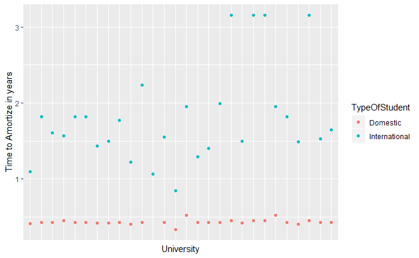

From the above result we can conclude that the time it takes to amortize for a domestic student stays around the same as well, while for international students, it takes 1-3 years.

###### Q2: Get a masters (international vs. domestic)

The following plot shows the tuition of each university in Ontario as a graduate student, both domestic and international.

###### Shows Domestic vs. International (used LEFT JOIN)

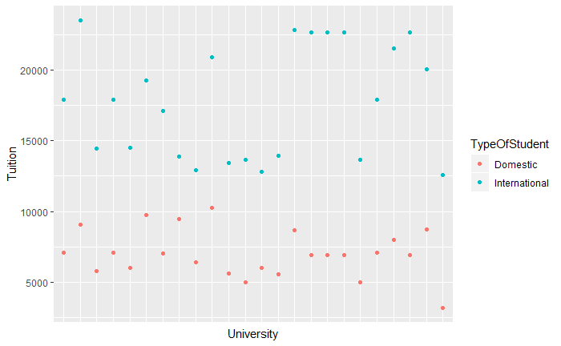

###### TIME TO AMORTIZE AS A GRADUATE

The following diagram shows the average time it takes to amortize as a graduate student from each university in Ontario, both domestic and international.

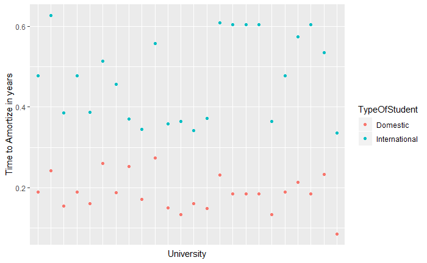